# Copper Futures Price Forecasting — Project Report

## Introduction

Copper is a widely-used leading indicator of global economic activity, with prices sensitive to industrial demand, currency movements, and speculative positioning. This project forecasts the front-month copper futures price (HG=F) over a medium-term horizon using publicly available macroeconomic signals.

**Research question:** Can macroeconomic and positioning indicators — the US Dollar Index, Brent crude oil, Chinese equity markets, and CFTC non-commercial net positioning — improve copper price forecasts beyond a univariate baseline?

## Method

### Variable Selection

| Variable | Source | Identifier |
| --- | --- | --- |
| Copper futures price | Yahoo Finance | HG=F |
| US Dollar Index (DXY) | Yahoo Finance | DX-Y.NYB |
| Brent crude oil | FRED | DCOILBRENTEU |
| Shanghai Composite | Yahoo Finance | 000001.SS |
| CFTC COT Managed Money net position | CFTC (manual) | Disaggregated futures |

Variables considered and rejected: Chinese PMI (no free API with sufficient history), COMEX inventory (not on FRED), US copper stocks (historical archive only), Strait of Hormuz/sulfur shipping risk.

### Data Pipeline

A medallion architecture (bronze → silver → gold) was implemented in SQL Server Express (`CopperForecast` database).

**Bronze** — Raw CSVs ingested from R (`01_fetch.R`, `02_load.R`). No transformations applied; data stored as-is for auditability.

**Silver** — Cleaned and standardised via stored procedure (`silver.load_silver`). Key transformations: dates cast from VARCHAR to DATE, forward-fill applied to handle non-trading days and data gaps, all series filtered to Friday weekly closes for consistent model alignment across series.

**Gold** — A view (`gold.master_table`) joins all five silver tables on date via INNER JOINs, producing a single analytic-ready dataset. A view was chosen over a physical table because the dataset is small (~1,000 rows), and the view always reflects the current silver state without requiring a separate load step.

Weekly refresh cadence: Saturdays, after all Friday US market closes and CFTC COT release (Fridays 3:30pm ET) are available. All five series were validated — no NULLs returned from `gold.master_table`.

## Contribution Record

All code in this project was written by Tye Routh. The table below documents independent effort per step and the nature of any guidance received. Bars are approximate (each block ≈ 10%).

| Step | Tye’s Contribution | Claude’s Role |
| --- | --- | --- |
| Database & schema design | `█████████░ 90%` | Confirmed medallion architecture was appropriate; no code authored |
| Data fetching (`01_fetch.R`) | `████████░░ 80%` | Advised on fredr/tidyquant API usage; all code written independently |
| Bronze layer loading (`02_load.R`) | `███████░░░ 75%` | Guided nested loop structure; corrected bracket notation, rbind syntax, string concatenation, and exdir uniqueness |
| Silver layer DDL | `█████████░ 90%` | Reviewed for correctness; not authored |
| Silver stored procedure | `███████░░░ 70%` | Explained forward-fill CTE concept and COT recursive date spine; corrected 4 syntax/logic issues (column name mismatch, CTE chain syntax, wrong table reference, copy-paste in CATCH block) |
| Gold layer view | `████████░░ 85%` | Explained view vs table tradeoff; advised `CREATE OR ALTER VIEW` for re-runnability; flagged dxy alias inconsistency; all SQL written independently |
| Data validation (NULL check) | `█████████░ 95%` | Explained INNER JOIN behaviour conceptually; query written and executed independently |

*The project report and README were authored by Claude at Tye’s direction.*

## Results

### Exploratory Analysis

**Copper futures price — 2006 to present**

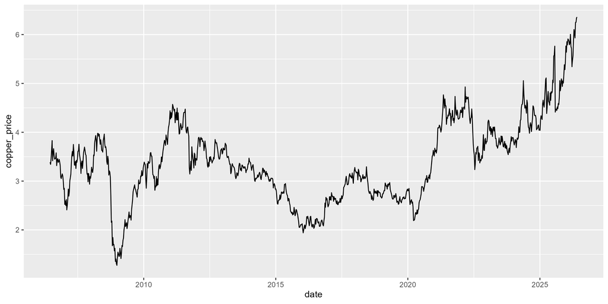

Copper price time series

**Pairwise correlations across all variables**

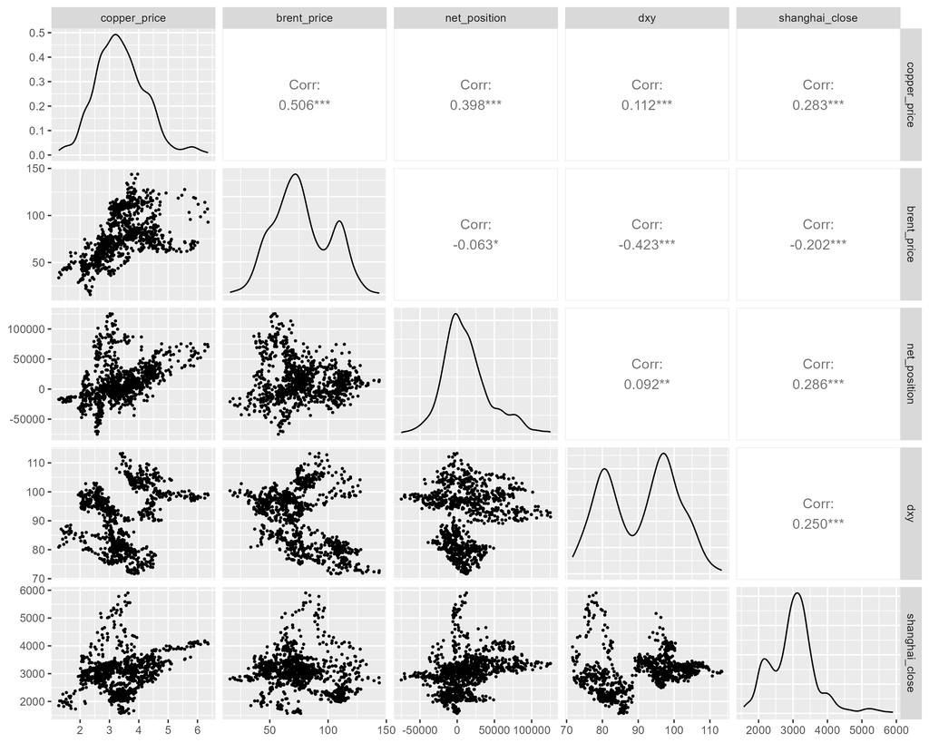

Pairwise correlation plot

DXY was binned into three equal-width regimes based on its distribution: Low (dominant 2007–2014, post-GFC quantitative easing), Medium (2015–2021 and 2025), and High (2022–2024, Fed rate-hiking cycle). These regimes are economically coherent and will be used as interaction terms in the model, with Medium as the reference category.